# Integration and Expectation

Seoncheol Park

11/29/2019

# 적분과 기댓값

## 리만적분(Riemann integral)

구간 $[a,b]$에서 함수 $f(x)$의 **리만적분(Riemann integral)**은 부분합의 극한으로 정의된다. 우리는 구간 $[a,b]$를 $a=x_{0}<x_{1}<\ldots <x_{n} =b$로 나무어 다음과 같은 합을 만들 수 있다.

$$\begin{equation}
\sum_{i=1}^{n}f(\xi_{i})\Delta x_{i}.
\tag{1}
\end{equation}$$

이 때 $\xi_{i}$는 $i$번째 구간 $[x_{i-1},x_{i})$에 있는 점이며 $\Delta x_{i}=x_{i}-x_{i-1}$이다. $\xi_{i}$와 $\Delta x_{i}$는 $n$과도 관련이 있음을 알아두자. 그러나 표기의 간편성을 위해 생략하기로 한다. 그러면 $\xi_{i}$를 어떻게 선택하는지와 상관없이 $n\rightarrow\infty$이고 $\max_{1\leq i \leq n}\Delta x_{i} \rightarrow 0$일 때 $f$를 **리만적분 가능(Riemann integrable)**하다고 말한다.

리만적분성은 $f$가 꽤 regular함을 요구한다. 즉 함수가 모든 지점에서 불연속일 경우, 리만적분은 잘 작동하지 않게 된다. (Shima 2016) $x$가 유리수일 때 0, 아닐때 1을 갖는 함수 $f(x)$가 있다고 하자. 그러면 식 (1)의 극한 $\int_{0}^{1}f(x)dx$는 중간값을 어떻게 고르냐에 따라 값이 달라지므로 리만적분 가능하지 않다. 모든 $i$에 대해 $\xi_{i}$를 유리수로 고르면 극한의 0이되나, 반대로 모든 $i$에 대해 무리수로 $\xi_{i}$를 잡을 경우 극한은 1이 된다. 그리고 $xi_{i}$를 유리수와 무리수를 섞어 잡을 경우 극한은 존재하지 않게 된다.

## 리만 적분의 한계정(limitation of Riemman integral)

전형적인 적분(integral) $\int_{A}f(x)dx$는 다음으로 구성되어있다.

- $A$: the set of integration (or the domain of integration)
- $f(x)$: the integrand
- $dx$: the integrator

다시 말해서, 적분이란 것은 연속적으로 변하는 물체들의 합인 것이다. 이는 역사적으로 적분기호 $\int$가 합을 뜻하는 sum의 $S$에서 온 것에서도 확인할 수 있다. 이 적분은 다음
$$\sum_{\alpha\in I}\max_{x\in A_{\alpha}}f(x)|A_{\alpha}| \text{ or } \sum_{\alpha\in I}\min_{x\in A_{\alpha}}f(x)|A_{\alpha}|$$
을 근사한다. 이 때 우리는 적분을 하고자 하는 집합 $A$를 disjoint set으로 나눌 수 있다, 즉 $A=\bigcup_{\alpha\in I}A_{\alpha}$로 나눌 수 있다고 가정하고 각 집합 $A_{\alpha}$ 에서 $f$는 거의 상수라고 가정한다. 여기서 우리는 $|A_{\alpha}|$를 집합 $A_{\alpha}$의 size라고 하자. 그리고 $\max_{x\in A_{\alpha}}f(x)$ 또는 $\min_{x\in A_{\alpha}}f(x)$를 $A_{\alpha}$에서의 함수값들을 대표하는 값으로 선택된 것이라 생각해보자. 가장 쉽게 질문할 수 있는 것은 ‘어떻게 set의 size를 정할 것인가?’ 라는 문제가 있다.

**리만 적분(Riemman integral)**에서는 interval (또는 rectangle, cube 등등)들의 size만 측도(measure)하면 된다.

**Example 1 (정의역과 치역이 1차원인 함수에서의 리만 적분)** $f$를 $\mathbb{R}$에서 정의된 함수고 정의역이 $[a,b]$라고 하자. 그러면 우리는 구간 $[a,b]$를 더 잘게, $[x_{0}=a,x_{1}], [x_{1},x_{2}],\ldots, [x_{n-1},x_{n}=b]$로 나누고 적분을 다음 값으로 근사한다.
$$\sum_{i=1}^{n}f(x_{i})|x_{i}-x_{i-1}|.$$
이 합의 극합이 적분값이 되며 우리는 이 적분을 리만 적분이라고 부른다. 여기서는 $\mathbb{R}$에서의 집합들의 크기(size)를 측도하기 위해 interval을 사용하였다.

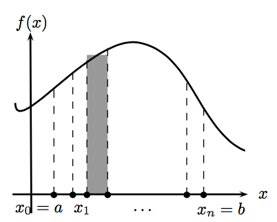

Figure 1: 1차원 공간의 정의역을 자르는 방법.

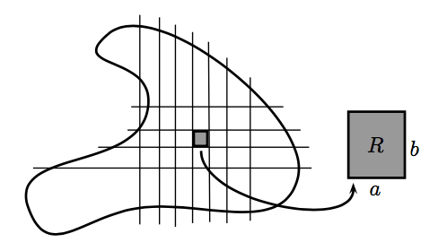

Figure 2: 2차원 공간의 정의역을 자르는 방법. 이 경우에는 사각형의 면적이 집합의 크기가 된다.

그러나, 불연속 함수의 경우에는 interval (또는 rectangle, cube 등등)의 크기를 재는 것이 적분을 정의하기에 충분치 않을 수도 있다. 따라서 우리는 먼저 집합의 크기를 정의하는 것 부터 다시 정의할 필요가 있다. 이제부터 ’집합의 크기(size)’를 집합의 **측도(measure)**라고 부를 것이다. **측도함수(measure function)** $m$는
$$m:\mathcal{M}\rightarrow [0,\infty], \mathcal{M}\subseteq\mathcal{P}(\mathbb{R}^{n})$$
이다. 즉 $\mathcal{M}$dms $\mathcal{P}(\mathbb{R}^{n})$의 subcollection이다. 이제 여기서의 목표는 적분이론에 잘 맞는 적절한 $m,\mathcal{M}$을 찾는 것이다. 그런데 우리가 모든 $\mathcal{P}(\mathbb{R}^{n})$에 대해 $m$을 정의할 수 있을까? 만약 그렇지 않다면, 적어도 우리는 $\mathcal{M}$에서의 측도 $m$이 interval이나 rectangle, open set, compact set 등 좋은 ’집합’들에서 모두 잘 정의되게끔 구성하고자 한다. 더 나아가, 우리는 이 적분함수 $m$을 우리 직관에 일치하도록 확장시키고자 한다. 그 직관이란,

- $m(\emptyset)=0$
- $m([a,b])=b-a$ 또는 $m(\text{Rectangle})=|\text{vertical side}|\times |\text{horizontal side}|$
- 만약 $A\subset B$인 경우 $m(A)\leq m(B)$
- 만약 $A,B$가 disjoint인 경우 $m(A\cup B)=m(A)+m(B)$
- 더 나아가, 우리는 측도가 countable additivity를 갖길 원한다. 즉 $A_{i},i=1,2,\ldots$가 disjoint이면 $\sum_{i=1}^{m}=m(\cup_{i=1}^{\infty}A_{i}).$

정리하면, 만족스러운 적분이론을 얻기 위해 우리는 $\mathbb{R}^{n}$에서의 충분히 큰 subset들의 class에 대해 잘 정의되는 측도를 구성하고자 한다. 그러면 여기서 리만 적분으로는 불충분한 점들을 몇 가지 짚고 넘어가고자 한다.

우선, 리만 적분이 가능하려면, ‘대부분의’ 작은 interval에서 $\max f - \min f$가 매우 작아야한다. 즉, 리만 적분 가능성은 함수의 연속성과 관련이 있다. 실제로 함수 $f$가 리만 적분 가능하려면 $f$가 거의 모든 지점에서 연속이어야 한다(이는 필요충분조건이다).

**Example 2 (리만 적분이 안되는 함수)** 다음과 같이 함수 $f_{\text{Dir}}(x)$를 정의하자
$$f_{\text{Dir}}(x) =
\begin{cases}
1 & \text{if $x\in\mathbb{Q}$} \\
0 & \text{if $x\in\mathbb{Q}^{c}$.}\\
\end{cases}$$

그리면 임의의 구간 $I\subset\mathbb{R}$에 대해
$$\max_{x\in I}f_{\text{Dir}}(x) =1 \text{ and } \min_{x\in I}f_{\text{Dir}}(x) =0$$
이므로 $f_{\text{Dir}}(x)$는 리만적분이 가능하지 않다. 참고로 함수 $f_{\text{Dir}}(x)$는 어디에서도 연속이 아니다.

두 번째로, 리만 적분 이론에서는 적분의 정의역(domain)을 분해하기 위해 오로지 interval, rectangle 또는 cube 등등만을 고려한다. 그래서 우리는 interval을 어떻게 측도해야할지 알아야 한다. 그러나 어떤 함수드에서는, 다른 형태로 정의역을 분해하는 것이 좀 더 자연스러울 때가 있다. 예를 들면, 우리가 $\mathbb{Q}$ 또는 $\mathbb{Q}^{c}$에서의 측도를 정의하고자 할 때, 가장 자연스럽게 생각할 수 있는 것으로는 다음과 같은 적분이 있다.
$$\int_{0}^{1}f_{\text{Dir}}(x)dx:=1\cdot |\mathbb{Q}\cap [0,1]| + 0\cdot |\mathbb{Q}^{c}\cap [0,1]|.$$

마지막으로, 우리가 다음과 같은 함수들의 수열 $\{f_{n}:[0,1]\rightarrow\mathbb{R} \}$을 정의했을 때,
$$f_{n}(x) :=
\begin{cases}
1 & \text{if $x=p/q$ where $p,q\in\mathbb{Z}$ and $q\leq n$} \\
0 & \text{otherwise.}\\
\end{cases}$$

$f_{n}$들은 유한히 많은 점들을 제외하고 모두 연속이므로 리만 적분가능하다. 더불어 $n\rightarrow \infty$일 때 $f_{n}\rightarrow f_{\text{Dir}}$이다. 그러나 앞서 살펴본대로 $f_{\text{Dir}}$은 리만 적분 가능하지 않다. 이 예는 모든 함수들의 수열이 리만 적분 가능하더라도, 그것의 극한은 리만 적분 가능하지 않을 수도 있다는 것을 보여준다. 단 $\{f_{n}\}$이 $f$로 uniform converge 하는 경우에는 $f$는 항상 리만 적분 가능하다.

## 르베그 적분(Lebesgue integral)

르베그 적분은 리만적분의 단점들을 극복해 줄 뿐만 아니라 $L^{p}$ 공간이라고 하는 힐버트 공간의 specific class를 구성하는 데 필요한 기본적인 토대를 제공한다. (Shima 2016)

르베그 적분이 갖고 있는 중요한 점들 중 하나는 적분과 극한의 순서를 매우 약한 조건 하에서도 바꿔줄 수 있게 한다는 것이다. 실제로, 리만 적분에서는 다음의 적분 순서를

$$\begin{align}
\lim_{n\rightarrow\infty}\int_{-\infty}^{\infty}f_{n}(x)dx &= \int_{-\infty}^{\infty}\Bigg[ \lim_{n\rightarrow\infty}f_{n}(x) \Bigg] x \\
\sum_{n=1}^{\infty}\int_{-\infty}^{\infty}f_{n}(x)dx &= \int_{-\infty}^{\infty}\Bigg[\sum_{n=1}^{\infty}f_{n}(x)\Bigg] dx
\end{align}$$

바꾸기 위해 좀 더 강한 조건이 필요하다. 위 식의 등호가 성립하려면

- 리만 적분: $\lim_{n\rightarrow\infty}f_{n}(x)$와 $\sum_{n=1}^{\infty}f_{n}(x)$가 **uniformly convergent**
- 르베그 적분: $\lim_{n\rightarrow\infty}f_{n}(x)$와 $\sum_{n=1}^{\infty}f_{n}(x)$가 **pointwise convergent**

이 말인 즉슨 불연속점을 갖고 있거나 발산하는 함수의 적분을 르베그의 방법이 좀 더 쉽게 다룰 수 있게 해준다는 것이다. (Shima 2016)

르베그 적분의 기본 아이디어는 $x$축대신 $y$축을 등간격으로 잘라 부분학의 극한을 구하는 방법이 있다.

$$\begin{equation}
\sum_{i=1}^{\infty}y_{i}\mu\{ f^{-1}(A_{i}) \}.
\tag{2}
\end{equation}$$

이 때 $y_{i}$는 $i$번째 $y$구간에서의 점을 나타내며 $\mu$는 **르베그 측도(Lebesgue measure)**가 된다. 즉, 각각의 $y$ 구간에 대해 우리는 중간값 $y_{i}$를 취하며 $A_{i}$에 대한 $f$의 역상 $f^{-1}(A_{i})$의 르베그 측도로 곱한다. 아래 그림에서는 $f^{-1}(A_{i}) = [a,b]\cup [c,d]$이다. 그리고 이에 대응되는 르베그 측도는 $\mu\{f^{-1}(A_{i}) \}= (d-c) + (b-a)$이다. 결국 해당 부분의 부분합은 $y_{i} \times \{ (d-c) + (b-a)\}$인 것이다. 이런 방식의 적분을 **르베그 적분(Lebesgue integral)**이라고 부른다.

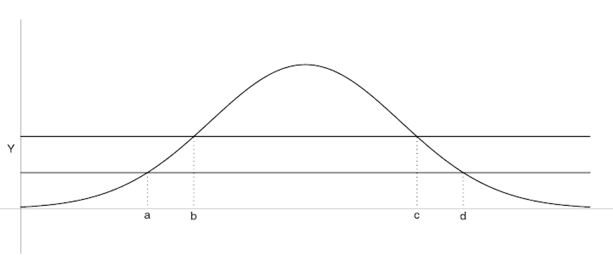

Figure 3: 가로선은 y를 등간격으로 잘라낸 구간 A를 의미한다. 그러면 A의 inverse image of f는 [a,b]와 [c,d]의 합집합에 대응된다.

$x$축 대신 $y$축을 분할하는 것의 장점은 $f$가 $x$에 대해 더이상 잘 행동하는 함수일 필요가 없다는 것이다. 다시 앞서 리만 적분에서 등장한 적분 문제를 생각해보자. $A_{i}$와 $A_{j}$를 각각 $y=0$, $y=1$에 대응되는 구간이라고 한다면 앞서 적분 식 (2)은 $y_{i}\mu\{ f^{-1}(A_{i}) \} + y_{j}\mu\{ f^{-1}(A_{j}) \}$가 된다. 이 때 $y_{i}$, $y_{j}$는 $A_{i}$, $A_{j}$의 중간값에 해당된다. $f^{-1}(A_{i})$과 $f^{-1}(A_{j})$는 각각 $[0,1]$에서 유리수와 무리수의 집합에 대응되며 그들의 르베그 적분은 각각 0과 1이다. 따라서 최종 르베그 적분값 $\int_{0}^{1}f(x)dx$는 존재하며 1이다. (왜 이렇게 되는지는 측도부분 참고)

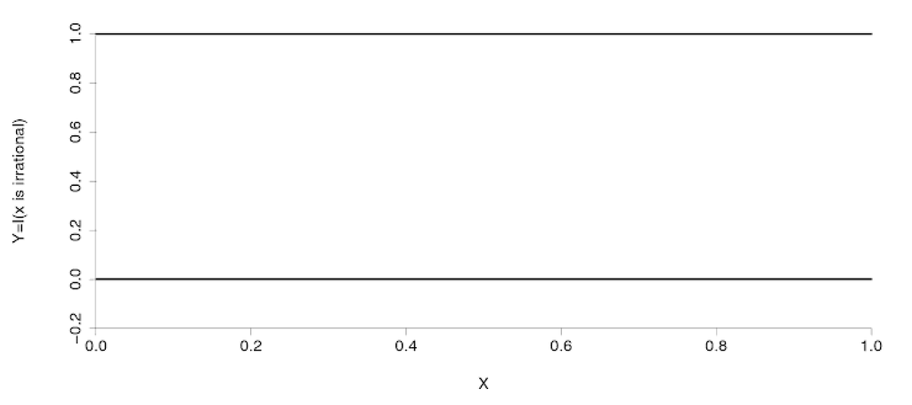

Figure 4: x가 무리수와 유리수일 때 1, 0을 주는 함수의 적분을 생각해보자. 르베그 적분의 방법으로 y축을 분할하면 충분히 작은 구간에서 함수값이 0인 경우와 1인 경우를 분리시킬 수 있다. 그 다음에는 구간 [0,1] 사이에서의 무리수들의 집합의 르베그 측도(1)와 유리수들의 집합의 르베그 측도(0)을 재면 된다.

이것을 더 확장하여 선으로 정의된 공간이 아닌 임의의 공간 $\Omega$에서 정의된 르베그 측도뿐 아니라 임의의 측도 $\mu$에 대해서 $f$의 적분 또한 정의할 수 있다. 만약 $\mu$가 확률공간 $\Omega$에서 정의된 측도라고 한다면, 우리는 적분을 다음과 같이 정의할 수 있다.
$$\int f(\omega)d\mu (\omega).$$
이것은 $y$축을 등간격으로 분할하고 (2)처럼 합을 취한 후 $y$축의 분할 넓이가 0이 되도록 극한을 취함으로써 얻을 수 있다. 그런데 이 적분에는 두 가지 문제가 있다.

1. 극한이 존재하지 않을 수도 있고
2. 극한이 중간값 $y_{i}$를 어떻게 고르는지에 따라 바뀔 수도 있다.

이러한 문제점은

1. $f$를 음이 아닌 함수로 정의하고
2. $y$를 분할하는 구간을 현명하게 자름으로써 피할 수 있다.

다음은 Shima (2016) 에서 나오는 르베그 적분의 정의다.

**Definition 1 (르베그 적분)** $f(x)$를 measurable set $X$에서 정의된 음이 아닌 함수라고 하고 $X$의 finite number of subset으로

$$X = X_1 + X_2 + \ldots + X_n$$

분할하자. 그리고 $f_{k}=\inf_{x\in X_k}f(x)$로 정의해 다음과 같은 **르베그 합(Lebesgue sum)**

$$\sum_{k=1}^{n}f_{k}\mu(X_k)$$

을 구성하자. 그러면 $X$에서 $f(x)$의 **르베그 적분(Lebesgue integral)**은 다음과 같이 정의된다.

$$\int_{X}fd\mu \equiv \lim_{\max |f_k - f_{k-1}|\rightarrow 0} \Bigg[ \sum_{k=1}^{n}f_{k}\mu(X_k) \Bigg] ,$$

이 때 모든 partition들을 고려한다.

## “Almost everywhere” concept

르베그 측도에서는 측도 0인 집합들은 아무런 기여를 하지 못한다. 이러한 사실들은 가측함수들에서 **equality almost everywhere**라는 컨셉을 만들어준다. (Shima 2016)

**Definition 2 (Equality almost everywhere)** 같은 집합 $X$에서 정의된 함수들 $f(x)$, g(x)$가 measure $\mu(X)$에 대해

$$\mu\{x\in X; f(x) \neq g(x)\}=0$$

일 때 이들을 **equality almost everywhere**라고 부른다.

**Example 3** 다음과 같이 $x\in [0,1]$에서 유리수일 때 1, 무리수일 때 0을 갖는 함수를 생각해보자.

$$f(x) =
\begin{cases}
1 & x\in \mathbb{Q}\\
0 & \text{o.w.}
\end{cases}$$

모든 isolated point들은 null measure를 갖므로 $f(x)$는 equal to zero almost everywhere이다.

일반적으로 $X$에서 **almost everywhere**라는 개념은 어떤 성질이 measure zero인 집합을 제외한 $X$의 나머지 지점들에서 성립하는 것을 의미한다.

**Definition 3 (Convergence almost everywhere)** 집합 $X$에서 함수들의 수열 $\{ f_{n}(x) \}$를 생각해보자. 이 수열이

$$\lim_{n\rightarrow \infty}f_{n}(x) = f(x),$$

for all $x \in X$ except at points of measure zero라면 $\{ f_{n}(x) \}$는 $f(x)$로 **coverge almost everywhere**라고 한다.

**Example 4 (Convergence almost everywhere의 예)** 다음과 같이 정의된 함수열

$$f_n(x) = (-x)^{n} \qquad{0\leq x \leq 1}$$

$\{ f_{n}(x) \}$ 는 $f(x) \equiv 0$으로 coverge almost everywhere이다 (except at the point $x=1$).

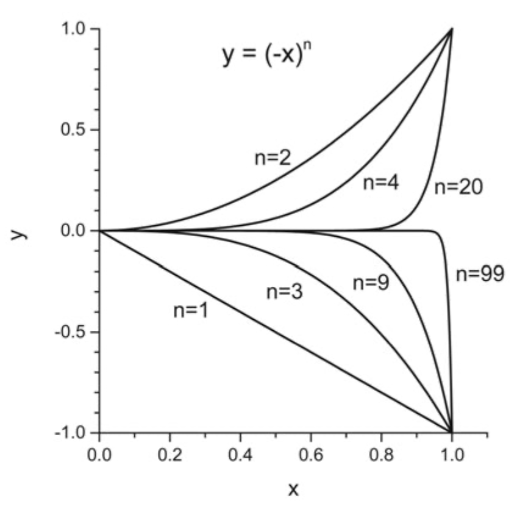

Figure 5: Converge almost everywhere function sequence.

## 적분의 성질(properties of integration)

다음은 Proschan (2016) 에서 나오는 적분의 성질이다. 다음에 나오는 함수들은 모두 $\mathcal{F}$-measurable이라고 가정한다.

1. **Linearity**: 만약 $c_1$, $c_2$가 상수들이라면,
- $\int \{ c_1 f_{1}(\omega) + c_2 f_{2}(\omega)\}d\mu (\omega) = c_1\int f_{1}(\omega)d\mu (\omega) + c_2\int f_{2}(\omega)d\mu (\omega)$ (오른쪽 항들이 $\infty - \infty$ 또는 $-\infty + \infty$가 아닐 때)
- $E(c_1 X_1 + c_2 X_2) = c_1 E(X_1) + c_2 E(X_2)$ (오른쪽 항들이 $\infty - \infty$ 또는 $-\infty + \infty$가 아닐 때)
2. Integrable과 absolutely integrable의 동치조건
- $\int f(\omega) d\mu(\omega)$가 존재하고 이것이 유한하다 $\Leftrightarrow$ $\int |f(\omega) | d\mu (\omega) <\infty$.
- $E(X)$가 존재하고 유한하다 $\Leftrightarrow$ $E(|X|)<\infty$.
3. Modulus inequality
- $|\int f(\omega) d\mu (\omega) | \leq \int |f(\omega)|d\mu(\omega)$.
- $|E(X)|\leq E(|X|)$.
4. Preservation of ordering
- 만약 $f(\omega)\leq g(\omega)$ for $\omega \notin N$, where $\mu(N)=0$, then $\int f(\omega)d\mu(\omega) \leq \int g(\omega)d\mu(\omega)$.
- 만약 $P(X\leq Y)=1$, then $E(X)\leq E(Y)$.
5. Integration term by term
- If either $f_n$ is nonnegative for all $n$ or $\sum_{n=1}^{\infty}\int |f_{n}(\omega)|d\mu(\omega)<\infty$, then $\int \sum_{n=1}^{\infty}f_{n}(\omega)d\mu(\omega) = \sum_{n=1}^{\infty}\int f_{n}(\omega)d\mu(\omega)$.
- If either $X_n$ is nonnegative for all $n$ or $\sum_{n=1}^{\infty}E(|X_n|)<\infty$, then $E(\sum_{n=1}^{\infty}X_{n})=\sum_{n=1}^{\infty}E(X_n)$.

## 르베그 수렴 정리(Lebesgue convergence theorem)

어떤 상황에서 적분과 극한의 순서를 바꿀 수 있을까? 즉 어떤 경우에

$$\begin{equation}
\lim_{n\rightarrow \infty} \int_{X}f_n d\mu = \int_{X}f d\mu
\tag{3}
\end{equation}$$

인가?

Shima (2016) 의 설명에 따르면 식 (3) 는 모든 $n$에서의 $f_n$과 $\lim_{n\rightarrow \infty}f_n$이 모두 Lebesgue integrable일 때에도 성립하지 않을 수도 있다고 한다. 예를 들면

$$f_n (x) =
\begin{cases}
0 & \text{at } x= 0,\\
n & \text{for } 0 < x <\frac{1}{n},\\
0 & \text{for } \frac{1}{n} \leq x \leq 1.
\end{cases}$$

라는 함수가 있다고 하면 $\{f_n\}$의 극한은 $f = \lim_{n\rightarrow \infty}f_n \equiv 0$, $\forall X\subseteq [0,1]$이어서 $\int_{X}fd\mu = 0$이 된다. 한편

$$\int_{X}f_n d\mu = \int_{0}^{\frac{1}{n}}n dx + \int_{\frac{1}{n}}^{1}0dx = n\cdot \frac{1}{n}=1$$

이므로 식 (3) 가 성립하지 않는다. 이 반례는 식 (3) 이 성립하려면 $\{f_n\}, f$가 르베그 적분가능한 것 이외에 추가 조건들이 필요하다는 것을 의미한다.

**Theorem 1 (단조수렴정리(MCT))** 1. null set $N$ $(\mu(N)=0)$ 바깥의 $\omega$에 대해 $f_{n}(\omega)\geq 0,\forall n$이고 $f_{n}(\omega)\uparrow f(\omega)$라고 하자. 그러면 $\int f_{n}(\omega)d(\omega)\uparrow \int f(\omega)d\mu(\omega)$이다.

2. 확률변수 버전으로는, 만약 모든 $n$에 대해 $P\{\omega: X_{n}(\omega)\geq 0 \forall n \text{ and } X_{n}(\omega)\uparrow X(\omega)\}=1$이라고 하자. 그러면 $E(X_{n})\uparrow E(X)$이다.

Shima (2016) 의 설명에 따르면 단조수렴정리는 르베그 적분의 경우에 $f_n (x)$에서 $f(x)$로 pointwise convergence함이 극한과 적분의 순서를 바꾸기 위해서 필요한 조건이라는 것을 의미하며, 리만적분에서는 uniform convergence가 필요함을 생각해 봤을 때 조건이 약해졌음을 알 수 있다.

단조수렴정리는 함수열 $\{f_n(x)\}$가 monotonically increasing해야 한다는 때때로 불편한 조건을 필요로 한다. 좀 더 일반적인 함수열, 즉 조건을 약하게 하여 non-monotone sequence의 경우에는 어떨 때 적분과 극한의 순서를 바꿀 수 있을까? 이럴 때에는 **지배수렴정리(Dominated convergence theorem, DCT)** 가 도움이 된다.

**Theorem 2 (지배수렴정리(DCT))** 1. null set $N$ $(\mu(N)=0)$ 바깥의 $\omega$에 대해 $f_{n}(omega) \rightarrow f(\omega)$이고 $|f_{n}(\omega) | \leq g(\omega)$, $\int g(\omega)d\mu(\omega) < \infty$일 때 $\int f_{n}(\omega)d\mu(\omega) \rightarrow \int f(\omega)d\mu(\omega)$이다.

2. 확률변수 버전으로는, 만약 모든 $n$에 대해 $P\{\omega: X_{n}(\omega)\rightarrow X(\omega) \text{ and } |X_{n}(\omega)|\leq Y(\omega) \forall n\}=1$이고 $E(Y)<\infty$라고 하자. 그러면 $E(X_{n})\rightarrow E(X)$이다.

Shima (2016) 의 설명에 따르면 지배수렴정리는 모든 $n$에 대해 $f_n$이 bounded from above **almost everywhere**라는 조건을 필요로 한다는 것을 보여주며, 이것은 단조수렴정리에 비해 완화된 조건이라고 볼 수 있다. 즉 단조수렴정리는 지배수렴정리의 특별한 경우이다.

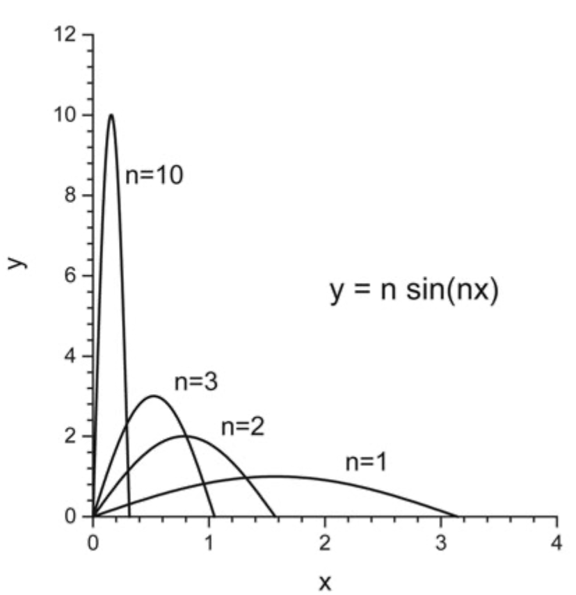

Figure 6: Plots of the function y=nsin(nx) for various n.

**Example 5 (지배수렴정리 관련 예제 (1))** Point set $X=(0,\pi]$에서 정의된 함수열 $\{f_n\}$을 생각하자. 이 때 $f_n$들은

$$f_n(x) =
\begin{cases}
n \sin nx & \text{for } 0 < x \frac{\pi}{n}\\
0 & \text{for } \frac{\pi}{n} \leq x \leq \pi
\end{cases}$$

$$\lim_{X}f_n d\mu = \int_{0}^{\pi}f_{n}(x)dx = 2$$

임을 한다. 따라서

$$\lim_{n\rightarrow \infty}\int_{X}f_n d\mu \neq \int_{X} \lim_{n\rightarrow \infty}f_n d\mu$$

이다. 즉, 모든 $n$에 대해 $|f_n|<g$를 만족하는 non-negative 함수 $g$가 존재하지 않기 때문에 이 함수열에 DCT를 적용할 수 없다.

**Example 6 (지배수렴정리 관련 예제 (2))** 구간 $X=[0,1]$에서 정의된 다음의 함수열 $\{f_n\}$을 다음과 같이 정의한다.

$$f_n(x) =
\begin{cases}
n^{\alpha} & \text{for } 0 \leq x \leq \frac{1}{n},\\
0 & \text{for } \frac{1}{n} < x \leq 1.
\end{cases}$$

그러면 $\{f_n\}$의 극한은 다음과 같다.

$$f(x) \equiv \lim_{n\rightarrow \infty}f_n (x) = 0 \qquad{\text{ at } x\neq 0.}$$

즉 $f(x)$는 $x=0$을 제외하고 $f(x)\equiv 0$이며 $x=0$에서는 null measure를 갖는다. 따라서 우리는 다음의 결과를 얻는다.

$$\int_{0}^{1}\lim_{n\rightarrow \infty}f_n (x) dx = \int_{0}^{1}f(x)dx = \int_{0}^{1}0 dx = 0.$$

한편

$$\int_{0}^{1}f_n(x)dx =n^{\alpha -1}$$

이므로

$$\lim_{n\rightarrow \infty} \int_{0}^{1}f_n (x) dx =
\begin{cases}
0 & (\alpha < 1)\\
1 & (\alpha = 1)\\
\infty & (\alpha >1)
\end{cases}$$

이 된다. 따라서 이 함수열의 경우는 $\alpha$에 따라 DCT가 실패할 수도 있다. $\alpha\geq 1$인 경우에는 DCT가 성립하지 않는다.

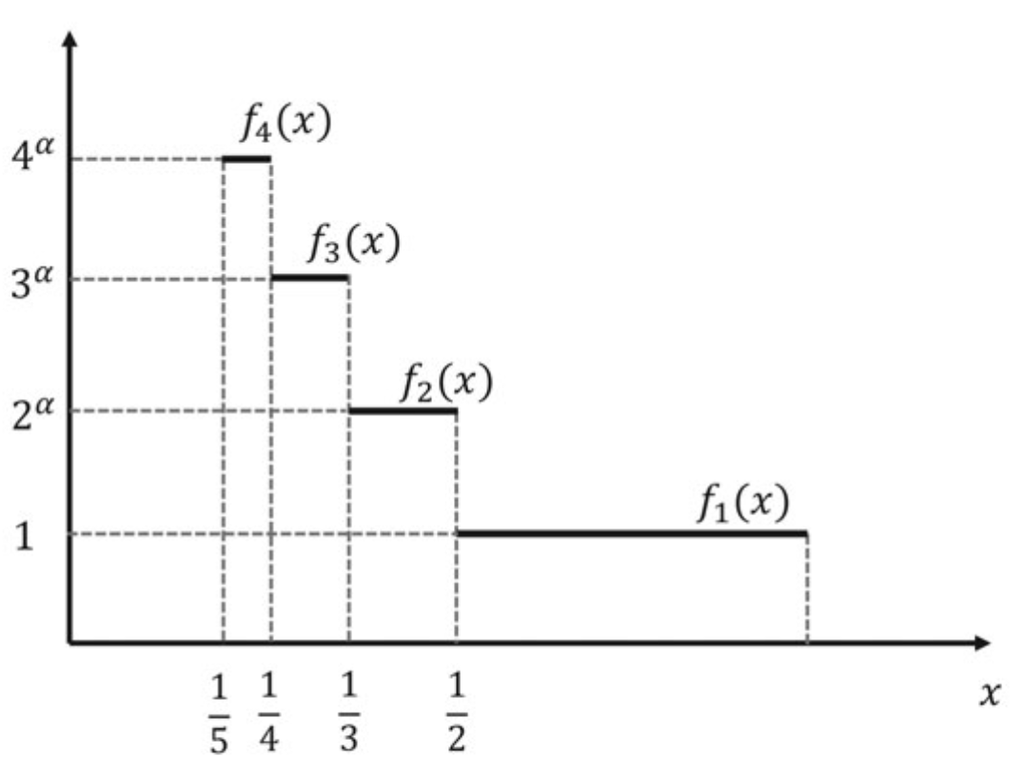

Figure 7: Plots of y=f_n(x) in remark.

*Remark.* DCT에서 간과할 수 있는 것이 모든 $n$에 대해 $|f_n | \leq g$를 만족하는 함수 $g$가 존재하지 않더라도 DCT가 성립할수도, 아닐수도 있다는 점이다.

다음과 같은 함수열 $\{f_n\}$을 생각해보자.

$$f_n (x) =
\begin{cases}
0 & \text{for } 0\leq x < \frac{1}{n+1}\\
n^{\alpha} & \text{for }\frac{1}{n+1} \leq x \leq \frac{1}{n}\\
0 & \text{for }\frac{1}{n} < x \leq 1.
\end{cases}$$

이 함수열의 극한은

$$f(x) \equiv \lim_{n\rightarrow \infty}f_n (x) = 0 \text{ almost everywhere}$$

이고 따라서

$$\int_{0}^{1}\lim_{n\rightarrow \infty}f_n (x) dx = \int_0^{1}f(x)dx = 0$$

이다. 한편

$$\int_{0}^{1}f_n(x)dx = n^{\alpha}\int_{\frac{1}{n+1}}^{\frac{1}{n}}dx =n^{\alpha}\Bigg( \frac{1}{n} - \frac{1}{n+1} \Bigg) = \frac{n^{\alpha - 1}}{n + 1}$$

이기 때문에 다음과 같은 결과를 의미한다.

$$\int_0^{1}f_n(x)dx = n^{\alpha} \int_{\frac{1}{n+1}}^{\frac{1}{n}}dx = n^{\alpha}\Bigg(\frac{1}{n} - \frac{1}{n+1} \Bigg) = \frac{n^{\alpha - 1}}{n + 1}.$$

따라서

$$\lim_{n\rightarrow \infty}\int_{0}^{1}f_n(x)dx =
\begin{cases}
0 & (\alpha <1),\\
0 & (1\leq \alpha < 2),\\
1 & (\alpha = 2),\\
\infty & (\alpha > 2).
\end{cases}$$

이 때 $1 \leq \alpha <2$인 경우를 살펴보자. 이 때 우리는 모든 $n$에 대해 $|f_n| \leq g$를 만족하는 적당한 함수 $g$를 찾을 수 없다. 다음과 같은 계단함수 $g(x)$

$$g(x) =
\begin{cases}
1 & \text{for }\frac{1}{2} < x\leq 1,\\
2^{\alpha} & \text{for } \frac{1}{3} < x\frac{1}{2},\\
3^{\alpha} & \text{for } \frac{1}{4} < x\frac{1}{3},\\
\vdots & \vdots\\
n^{\alpha} & \text{for } \frac{1}{n+1} < x\frac{1}{n},\\
\vdots & \vdots
\end{cases}$$

그러나 이 함수 $g$는 $1\leq \alpha <2$일 때 $[0,1]$에서 적분가능하지 않다. 실제로

$$\int_{0}^{1}g(x)dx = \sum_{n=1}^{\infty}\frac{n^{\alpha - 1}}{n + 1}=
\begin{cases}
0 & (\alpha < 1),\\
\infty & (1 \leq \alpha <2),\\
\infty & (\alpha \geq 2).
\end{cases}$$

즉 $1\leq \alpha <2$에서 DCT를 적용할 수 없지만 적분과 극한을 바꾸었을 때의 계산 결과가 일치한다.

지배수렴정리의 따름정리로 유계수렴정리(bounded convergence theorem, BCT)가 있다.

**Theorem 3 (유계수렴정리(BCT))** $X_{n}$이 확률변수이고 $P\{X_{n}(\omega)\rightarrow X(\omega)\}=1$이며 각 $n$에 대해 $P\{|X_{n}|\leq c\}=1$ 일 때 ($c$는 상수), $E(X_{n})\rightarrow E(X)$이다.

*Remark.* MCT와 DCT는 모든 적분에 대해 적용할 수 있음을 알아내는 것이 중요하다. 합들(sums)은 counting measure에 대한 적분들이므로 이것들에 대해서도 적용할 수 있다.

## 부등식들(inequalities)

확률론에서 부등식들은 중요한 역할을 하는데, 대부분의 일들은 다른 것들로부터 특정한 확률로 추정하는 문제들을 다루고 있기 때문이다.

**Lemma 2 (모멘트로부터 꼬리확률을 추정)** $g$가 음이 아니고, 감소하지 않는 함수이며 $E\{g(X)\}<\infty$라고 하자. $x>0$일 때
$$P(|X|>x)\leq \frac{E\{g(|X|)\}}{g(x)}$$
이다.

*Proof.*
$$\begin{eqnarray}
E\{g(|X|)\} &=& E\{g(|X|)\}I\{|X|>x\}\\
&=& g(x)EI\{|X|>x\}\\
&=& g(x)P(|X|>x).
\end{eqnarray}$$

$g$를 특수하게 설정할 경우 다음 정리를 얻는다.

**Theorem 4 (마르코프 부등식)** 어떤 $r>0$에 대해 $E|X|^{r}<\infty$라고 하자. 만약 $x>0$이면 다음 부등식이 성립한다.
$$P(|X|>x)\leq \frac{E|X|^{r}}{x^{r}}.$$

**Corollary 1 (체비셰프 부등식)** 만약 $X$가 평균 $\mu$, 분산 $\sigma^{2}$을 갖는 확률변수라면 $c>0$에 대해 $P(|X-\mu|\geq c) \leq \sigma^{2}/c^{2}$이다.

**Theorem 5 (젠슨 부등식)** $f(x)$가 convex 함수이고 $X$는 유한한 평균 $\mu$를 갖는 확률변수라고 하자. 만약 $E(|f(X)|)<\infty$이면, $E\{f(X)\}\geq f\{E(X) \}$이다.

**Corollary 2 (젠슨 부등식의 따름정리)** 만약 $X$가 어떤 확률변수이고 $p\geq 1$이면 $E(|X|)\leq \{ E(|X|^{p}) \}^{1/p}$이다.

**Proposition 1 (Holder의 부등식)** 만약 $p >0 , q >0$이고 $\frac{1}{p} + \frac{1}{q} = 1$이라면,

$$\begin{equation}
E(|XY|) \leq \{E(|X|^{p}) \}^{\frac{1}{p}}\{E(|X|^{q}) \}^{\frac{1}{q}}.
\end{equation}$$

**Corollary 3 (Schwarz의 부등식)** 만약 $X$, $Y$가 확률변수들이라면,

$$E(|XY|) \leq \sqrt{E(X^2)E(Y^2)}.$$

**Proposition 2** $(|X| + |Y|)^{p} \leq 2^{p}(|X|^{p}+|Y|^{p})$ 이고 $E(|X|+|Y|)^{p} \leq 2^{p}\{ E(|X|^{p}) + E(|Y|^{p}) \}$이다.

**Proposition 3 (Minkowski의 부등식)** 만약 $p\geq 1$이라면

$$\begin{equation}
\{E(|X+Y|^{p}) \}^{\frac{1}{p}}\leq \{E(|X|^{p}) \}^{\frac{1}{p}} + \{E(|Y|^{p}) \}^{\frac{1}{p}}.
\end{equation}$$

## Iterated integrals and more on independence

**Definition 4 (sigma-finite)** 가측공간 $(A,\mathcal{A}, \mu)$에서의 측도 $\mu$는 만약 $A=\cup_{i=1}^{\infty}A_{i}$, where $\mu(A_{i})<\infty$일 때 **sigma-finite**라고 한다.

**Theorem 6 (Tonelli의 정리)** 만약 $\mu_{i}$가 $\sigma$-finite이고 $g(a_1, a_2)$가 nonnegative and measurable w.r.t. $\overline{\mathcal{A}_{1} \times \mathcal{A}_{2}}$이라면, $\int g(a_1, a_2)d\overline{\mu_{1}}(a_1)$이 measurable w.r.t. $\overline{\mathcal{A}_{2}}$이고

$$\begin{equation}
\int \int_{A_1 \times A_2}g(a_1, a_2)d(\overline{\mu_{1} \times \mu_{2}}) = \int \Bigg[ \int g(a_1, a_2) d\overline{\mu_{1}}(a_1) \Bigg]\overline{\mu_{2}}(a_2).
\tag{4}
\end{equation}$$

이것은 적분이 유한한지와 상관없이 성립한다.

**Theorem 7 (Fubini의 정리)** 만약 $\int \int_{A_1 \times A_2}|g(a_1, a_2)|d(\overline{\mu_{1} \times \mu_{2}})<\infty$이고 $\mu_1$과 $\mu_2$가 $\sigma$-finite 측도들이면, $\int g(a_1, a_2)d\overline{\mu_{1}}(a_1)$이 measurable w.r.t. $\overline{\mathcal{A}_{2}}$이고 식 (4) 가 성립한다.

## Densities

**Definition 5 (확률밀도함수)** 만약 확률변수 $X$의 분포함수 $F(x)$가 $F(x) = \int_{-\infty}^{x}f(t)dt$ for all $x\in \mathbb{R}$을 만족하면 nonnegative function $f$를 **확률밀도함수(probabililty density function)**, 짧게 밀도라고 부른다.

**Proposition 4 (Density defines probability of any Borel set)** 만약 $f(x)$가 확률변수 $X$에 대한 확률밀도함수라면, 모든 1차원 보렐 집합 $B$에 대해 $P(X\in B) = \int_{B}f(x)dx$이다.

**Definition 6 (절대연속)** 확률변수 $X$의 확률측도 $\mu_{X}$는 Lebesgue measure 0을 갖는 모든 보렐 집합 $A$에 대해 $\mu_{X}(A)=0$일 경우 르베그 측도에 대해 **절대연속(absolute continuous)**이라고 한다.

**Definition 7 (이변량 밀도)** 만약 $f(x,y)$가 nonnegative이고 $P(X\leq x, Y\leq y)=\int_{\mathbb{R}^{2}}f(s,t)I(s\leq x, t\leq y)d(s\times t)$ for all $x\in \mathbb{R}$, $y\in\mathbb{R}$, where $s\times t$ denotes two-dimensional Lebesgue measure일 때, pair $(X,Y)$를 이변량 밀도 $f(x,y)$를 갖는다고 말한다.

## Keep it simple

Proschan, Michael A. 2016. *Essentials of Probability Theory for Statisticians*. CRC Press. https://www.ebook.de/de/product/25453130/michael_a_proschan_essentials_of_probability_theory_for_statisticians.html.

Shima, Hiroyuki. 2016. *Functional Analysis for Physics and Engineering*. Taylor & Francis Ltd. https://www.ebook.de/de/product/25483199/hiroyuki_shima_functional_analysis_for_physics_and_engineering.html.